# Data Quality Check Report

Insitute for Alpine Environment, Eurac Research

Report start at **2017-12-13 12:02:07**

### INPUT info:

File selected: **S4.dat**

You have also select these parameters:

- Data start from row: *5*
- The name of column is on row: *2*
- The datetime header is: *TIMESTAMP*
- The record header is: *RECORD*
- The datetime format is: *yyyy-mm-dd HH:MM*
- The sampling interval is: *15 min*

The folders are:

- Data folder: *H:/Projekte/Klimawandel/Experiment/data/2order/DQC_BrC_test_data/*
- Report folder: *H:/Projekte/Klimawandel/Experiment/data/2order/DataQualityCheckEuracAlpEnv/Report/*
- Output folder: *H:/Projekte/Klimawandel/Experiment/data/2order/DQC_BrC_test_data/test_output/*
- Support folder: *H:/Projekte/Klimawandel/Experiment/data/2order/DataQualityCheckEuracAlpEnv/Data/Support_files/*

Range file in support folder is called: *Range.csv*

You decide: *to write output file in output folder*

### OUTPUT:

#### Info empty file:

S4.dat has some obseravtion.

#### **Duplicated rows**

More details on: H:/Projekte/Klimawandel/Experiment/data/2order/DQC_BrC_test_data/test_output/Duplicated_S4.csv

#### **Overlap**

In S4.dat there isn’t any overlap!

#### **Missing dates**

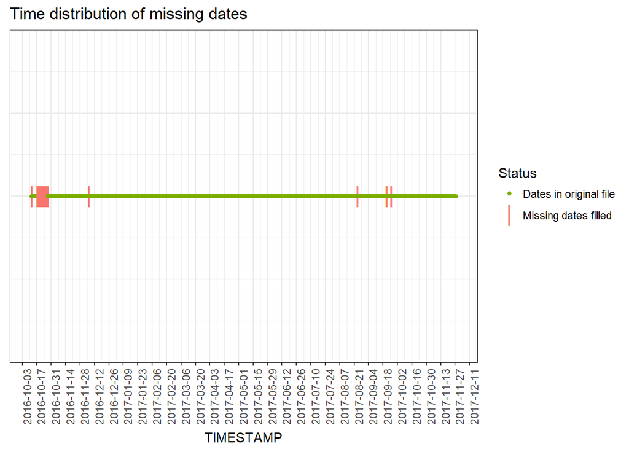

Statistics of missing dates:

| From | To | Number of Record |
| --- | --- | --- |
| 2016-10-12 11:00:00 | 2016-10-12 11:00:00 | 1 |
| 2016-10-17 15:00:00 | 2016-10-27 12:15:00 | 950 |
| 2016-12-06 15:00:00 | 2016-12-06 15:00:00 | 1 |
| 2017-08-24 12:15:00 | 2017-08-24 12:15:00 | 1 |
| 2017-09-21 12:15:00 | 2017-09-21 13:00:00 | 4 |
| 2017-09-21 14:00:00 | 2017-09-21 14:00:00 | 1 |
| 2017-09-21 14:45:00 | 2017-09-21 14:45:00 | 1 |
| 2017-09-26 06:45:00 | 2017-09-26 06:45:00 | 1 |

#### **Values out of admitted range**

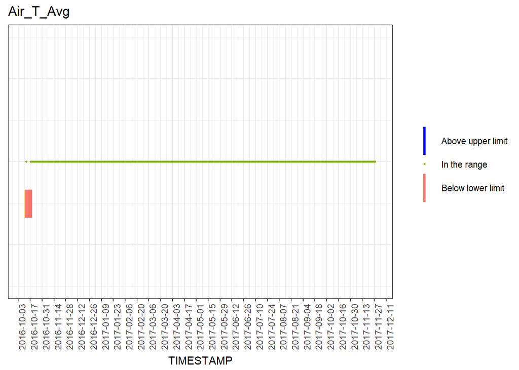

|  | From | To | Number of Record |
| --- | --- | --- | --- |
| Under lower limit | 2016-10-11 17:15:00 | 2016-10-12 10:45:00 | 71 |
| Under lower limit | 2016-10-12 11:30:00 | 2016-10-12 12:00:00 | 3 |
| Under lower limit | 2016-10-12 12:30:00 | 2016-10-17 09:45:00 | 470 |
| Under lower limit | 2016-10-17 10:30:00 | 2016-10-17 14:45:00 | 18 |

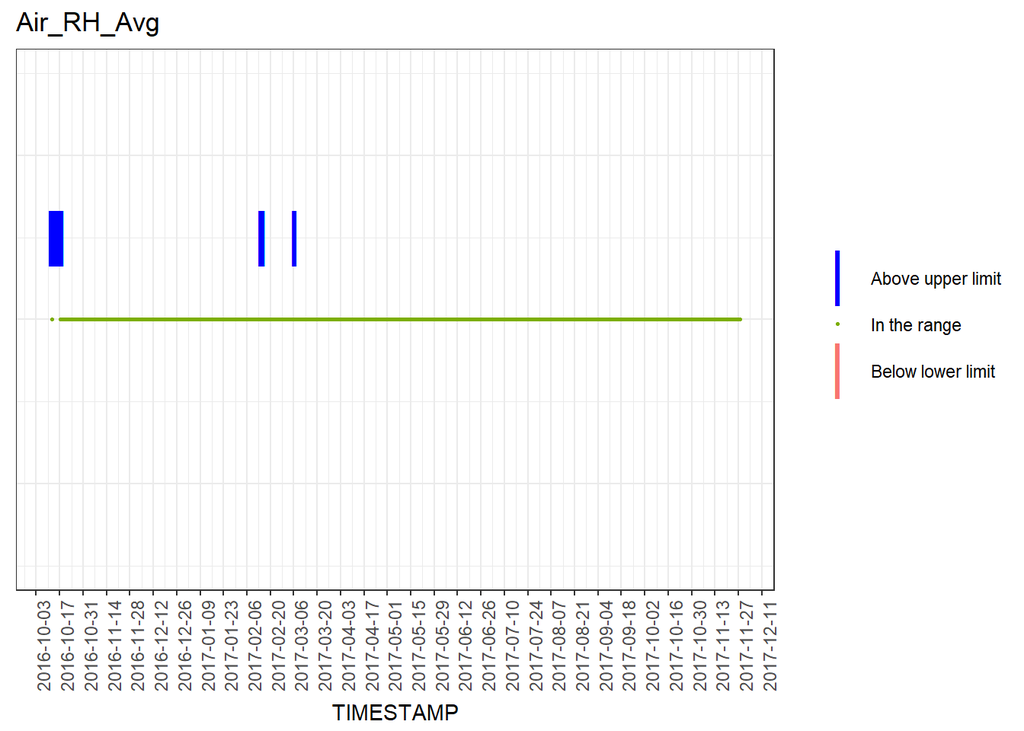

|  | From | To | Number of Record |
| --- | --- | --- | --- |
| Above upper limit | 2016-10-11 17:15:00 | 2016-10-12 10:45:00 | 71 |
| Above upper limit | 2016-10-12 11:30:00 | 2016-10-12 12:00:00 | 3 |
| Above upper limit | 2016-10-12 12:30:00 | 2016-10-17 09:45:00 | 470 |
| Above upper limit | 2016-10-17 10:15:00 | 2016-10-17 14:45:00 | 19 |
| Above upper limit | 2017-02-14 09:45:00 | 2017-02-14 09:45:00 | 1 |
| Above upper limit | 2017-02-14 23:00:00 | 2017-02-14 23:00:00 | 1 |
| Above upper limit | 2017-02-14 23:30:00 | 2017-02-14 23:30:00 | 1 |
| Above upper limit | 2017-02-15 01:45:00 | 2017-02-15 02:15:00 | 3 |
| Above upper limit | 2017-03-06 03:45:00 | 2017-03-06 03:45:00 | 1 |

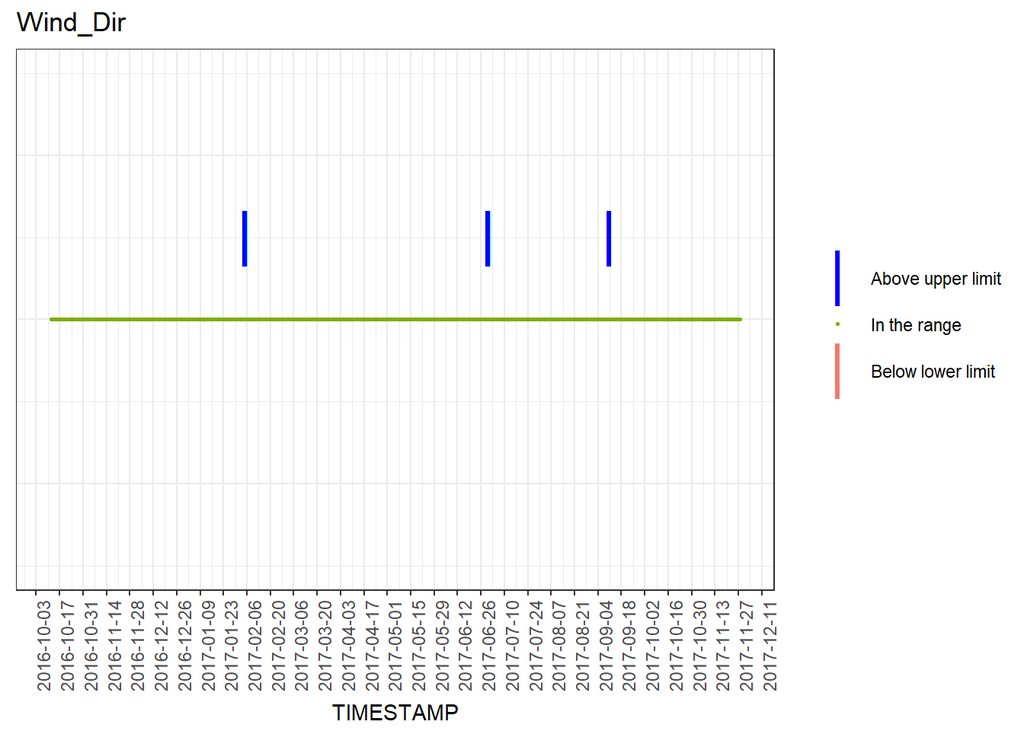

|  | From | To | Number of Record |
| --- | --- | --- | --- |
| Above upper limit | 2017-02-04 10:45:00 | 2017-02-04 12:15:00 | 7 |
| Above upper limit | 2017-06-30 00:30:00 | 2017-06-30 01:45:00 | 6 |
| Above upper limit | 2017-09-10 08:00:00 | 2017-09-10 08:00:00 | 1 |

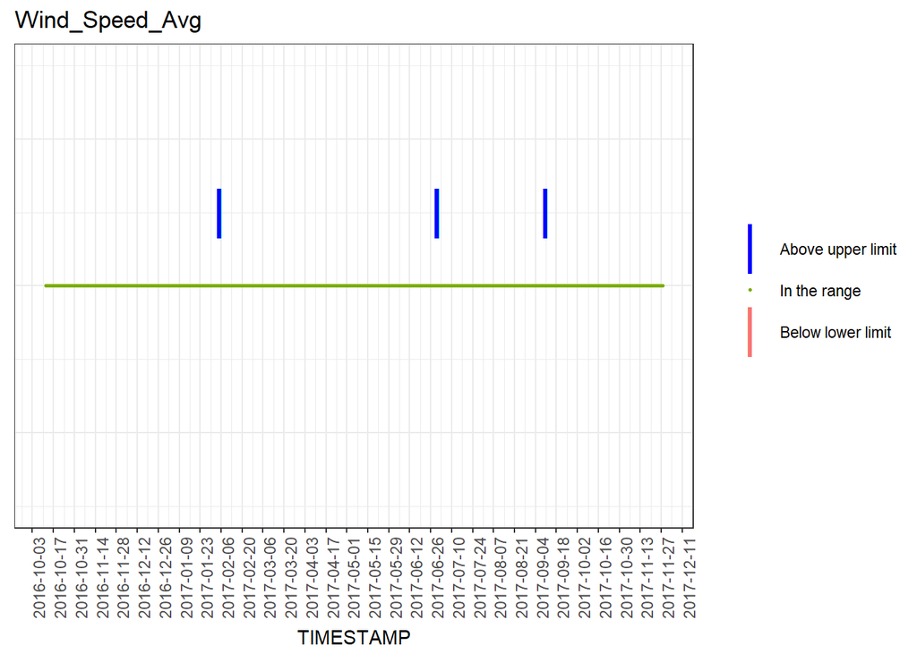

|  | From | To | Number of Record |
| --- | --- | --- | --- |
| Above upper limit | 2017-02-04 10:45:00 | 2017-02-04 13:15:00 | 11 |
| Above upper limit | 2017-06-30 00:30:00 | 2017-06-30 02:15:00 | 8 |
| Above upper limit | 2017-09-10 08:00:00 | 2017-09-10 08:15:00 | 2 |

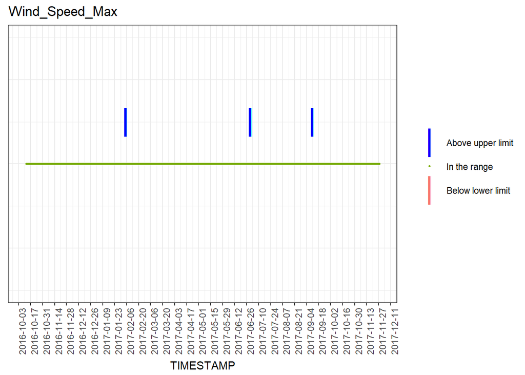

|  | From | To | Number of Record |
| --- | --- | --- | --- |
| Above upper limit | 2017-02-04 10:45:00 | 2017-02-04 13:15:00 | 11 |
| Above upper limit | 2017-06-30 00:30:00 | 2017-06-30 02:15:00 | 8 |
| Above upper limit | 2017-09-10 08:00:00 | 2017-09-10 08:15:00 | 2 |

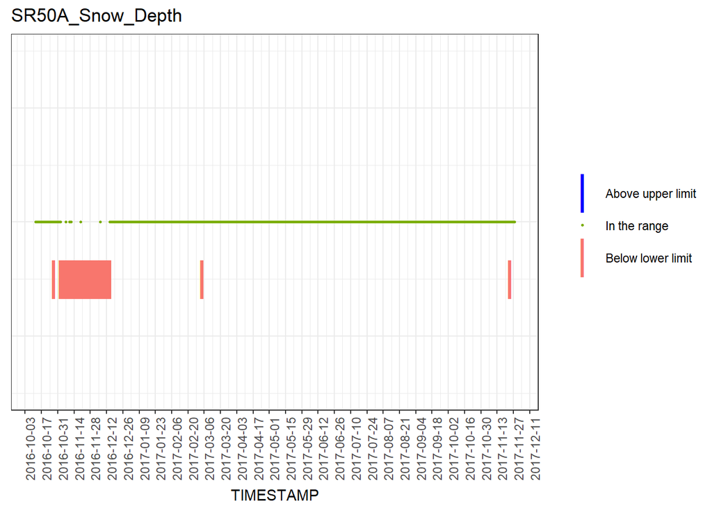

|  | From | To | Number of Record |
| --- | --- | --- | --- |
| Under lower limit | 2016-10-27 13:45:00 | 2016-10-27 13:45:00 | 1 |
| Under lower limit | 2016-11-02 12:00:00 | 2016-11-06 19:30:00 | 415 |
| Under lower limit | 2016-11-06 20:00:00 | 2016-11-06 23:45:00 | 16 |
| Under lower limit | 2016-11-07 00:15:00 | 2016-11-07 01:45:00 | 7 |
| Under lower limit | 2016-11-07 02:15:00 | 2016-11-10 04:45:00 | 299 |
| Under lower limit | 2016-11-10 06:00:00 | 2016-11-10 22:30:00 | 67 |
| Under lower limit | 2016-11-10 23:00:00 | 2016-11-11 06:15:00 | 30 |
| Under lower limit | 2016-11-11 06:45:00 | 2016-11-11 12:15:00 | 23 |
| Under lower limit | 2016-11-11 13:00:00 | 2016-11-11 13:15:00 | 2 |
| Under lower limit | 2016-11-11 14:15:00 | 2016-11-11 14:15:00 | 1 |
| Under lower limit | 2016-11-11 14:45:00 | 2016-11-19 13:00:00 | 762 |
| Under lower limit | 2016-11-19 13:30:00 | 2016-12-06 14:45:00 | 1638 |
| Under lower limit | 2016-12-06 15:15:00 | 2016-12-14 12:00:00 | 756 |
| Under lower limit | 2017-03-04 01:15:00 | 2017-03-04 01:45:00 | 3 |
| Under lower limit | 2017-11-23 18:30:00 | 2017-11-23 18:30:00 | 1 |

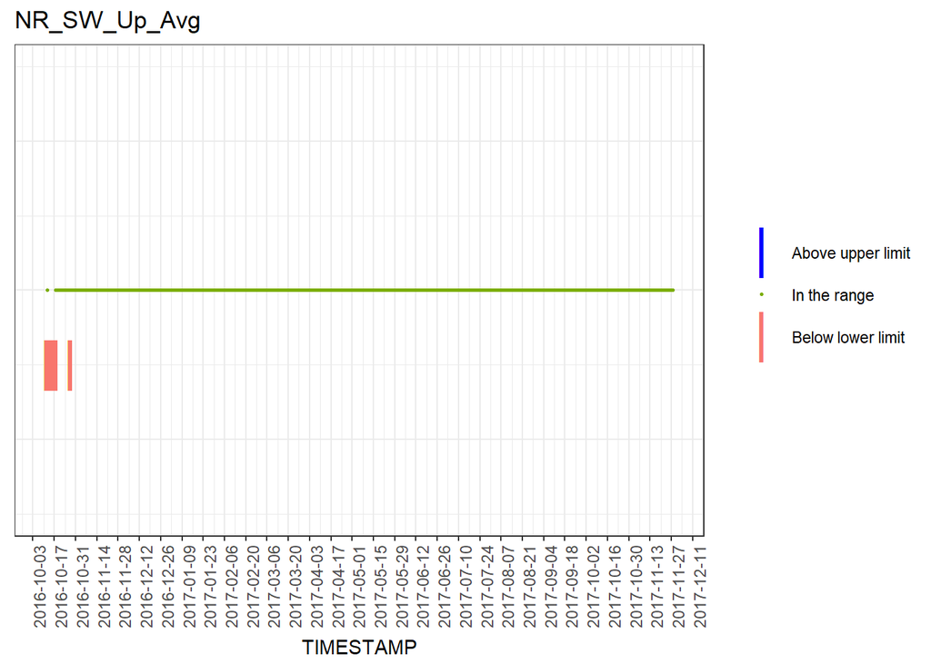

|  | From | To | Number of Record |
| --- | --- | --- | --- |
| Under lower limit | 2016-10-11 17:15:00 | 2016-10-12 10:45:00 | 71 |
| Under lower limit | 2016-10-12 11:15:00 | 2016-10-17 14:45:00 | 495 |
| Under lower limit | 2016-10-27 12:45:00 | 2016-10-27 14:15:00 | 7 |

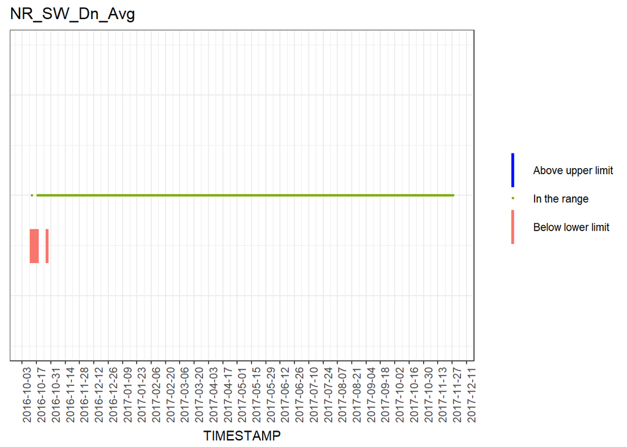

|  | From | To | Number of Record |
| --- | --- | --- | --- |
| Under lower limit | 2016-10-11 17:15:00 | 2016-10-12 10:45:00 | 71 |
| Under lower limit | 2016-10-12 11:15:00 | 2016-10-17 14:45:00 | 495 |
| Under lower limit | 2016-10-27 12:30:00 | 2016-10-27 14:15:00 | 8 |

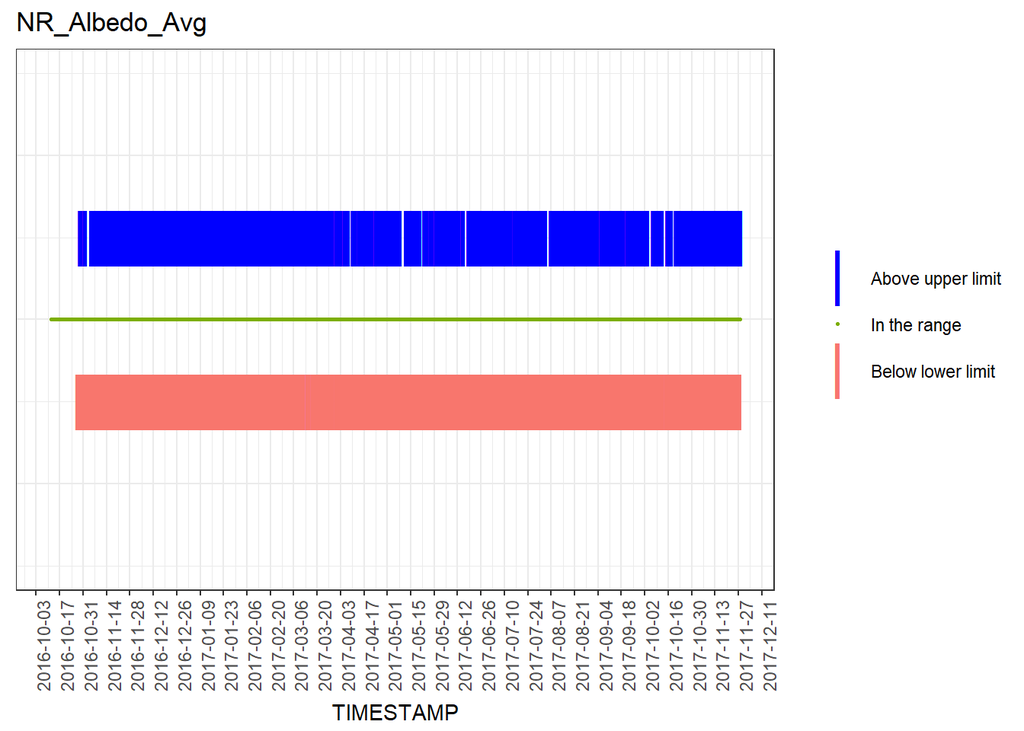

|  | From | To | Number of Record |
| --- | --- | --- | --- |
| Under lower limit | 2016-10-27 17:15:00 | 2016-10-27 17:15:00 | 1 |
| Under lower limit | 2016-10-28 17:15:00 | 2016-10-28 17:15:00 | 1 |
| Under lower limit | 2016-10-29 04:45:00 | 2016-10-29 04:45:00 | 1 |
| Under lower limit | 2016-10-29 05:30:00 | 2016-10-29 05:30:00 | 1 |
| Above upper limit | 2016-10-29 07:00:00 | 2016-10-29 07:00:00 | 1 |
| Under lower limit | 2016-10-30 07:00:00 | 2016-10-30 07:00:00 | 1 |
| Under lower limit | 2016-10-30 17:15:00 | 2016-10-30 17:15:00 | 1 |
| Under lower limit | 2016-10-31 04:30:00 | 2016-10-31 04:30:00 | 1 |
| Under lower limit | 2016-10-31 05:45:00 | 2016-10-31 05:45:00 | 1 |
| Under lower limit | 2016-10-31 06:15:00 | 2016-10-31 06:15:00 | 1 |
| Under lower limit | 2016-10-31 06:45:00 | 2016-10-31 07:00:00 | 2 |
| Above upper limit | 2016-10-31 17:15:00 | 2016-10-31 17:15:00 | 1 |
| Under lower limit | 2016-10-31 17:30:00 | 2016-10-31 17:30:00 | 1 |
| Under lower limit | 2016-10-31 23:00:00 | 2016-10-31 23:00:00 | 1 |
| Under lower limit | 2016-11-01 17:15:00 | 2016-11-01 17:15:00 | 1 |
| Under lower limit | 2016-11-02 20:45:00 | 2016-11-02 21:00:00 | 2 |
| Under lower limit | 2016-11-02 21:45:00 | 2016-11-02 21:45:00 | 1 |
| Under lower limit | 2016-11-03 07:00:00 | 2016-11-03 07:15:00 | 2 |
| Under lower limit | 2016-11-03 17:15:00 | 2016-11-03 17:15:00 | 1 |
| Under lower limit | 2016-11-03 20:00:00 | 2016-11-03 20:00:00 | 1 |
| Under lower limit | 2016-11-04 17:15:00 | 2016-11-04 18:15:00 | 5 |
| Under lower limit | 2016-11-04 19:15:00 | 2016-11-04 19:15:00 | 1 |
| Under lower limit | 2016-11-04 19:45:00 | 2016-11-04 19:45:00 | 1 |
| Under lower limit | 2016-11-04 20:15:00 | 2016-11-04 20:15:00 | 1 |
| Under lower limit | 2016-11-04 21:00:00 | 2016-11-04 21:00:00 | 1 |
| Under lower limit | 2016-11-04 21:45:00 | 2016-11-04 21:45:00 | 1 |
| Above upper limit | 2016-11-04 22:15:00 | 2016-11-04 22:30:00 | 2 |
| Above upper limit | 2016-11-04 23:00:00 | 2016-11-04 23:15:00 | 2 |
| Under lower limit | 2016-11-04 23:45:00 | 2016-11-04 23:45:00 | 1 |
| Above upper limit | 2016-11-05 00:00:00 | 2016-11-05 00:00:00 | 1 |

[output cut: 2295 more lines]

Report end at **2017-12-13 12:04:26**